# MP-02: Regression Analysis

Jalal Mansoori

2020-12-15

```r
#loading necessary libraries
library(tidyverse)
library(statsr)
```

### Exploring data

```r
#loading Ames Housing price dataset
df_hprice <- read_csv("train.csv")
#Checking dimensions of the dataset
dim(df_hprice)
```

```
## [1] 1460   81
```

So we have 1460 rows or (Information about 1460 houses) and 81 columns or (explanatory variables about each houses)

There’s an Id column in our dataset. Not relevant for analysis So removing it

```r
df_hprice <- subset(df_hprice, select= -Id)

head(df_hprice)
```

```
## # A tibble: 6 x 80
##   MSSubClass MSZoning LotFrontage LotArea Street Alley LotShape LandContour
##        <dbl> <chr>          <dbl>   <dbl> <chr>  <chr> <chr>    <chr>
## 1         60 RL                65    8450 Pave   <NA>  Reg      Lvl
## 2         20 RL                80    9600 Pave   <NA>  Reg      Lvl
## 3         60 RL                68   11250 Pave   <NA>  IR1      Lvl
## 4         70 RL                60    9550 Pave   <NA>  IR1      Lvl
## 5         60 RL                84   14260 Pave   <NA>  IR1      Lvl
## 6         50 RL                85   14115 Pave   <NA>  IR1      Lvl
## # … with 72 more variables: Utilities <chr>, LotConfig <chr>, LandSlope <chr>,
## #   Neighborhood <chr>, Condition1 <chr>, Condition2 <chr>, BldgType <chr>,
## #   HouseStyle <chr>, OverallQual <dbl>, OverallCond <dbl>, YearBuilt <dbl>,
## #   YearRemodAdd <dbl>, RoofStyle <chr>, RoofMatl <chr>, Exterior1st <chr>,
## #   Exterior2nd <chr>, MasVnrType <chr>, MasVnrArea <dbl>, ExterQual <chr>,
## #   ExterCond <chr>, Foundation <chr>, BsmtQual <chr>, BsmtCond <chr>,
## #   BsmtExposure <chr>, BsmtFinType1 <chr>, BsmtFinSF1 <dbl>,
## #   BsmtFinType2 <chr>, BsmtFinSF2 <dbl>, BsmtUnfSF <dbl>, TotalBsmtSF <dbl>,
## #   Heating <chr>, HeatingQC <chr>, CentralAir <chr>, Electrical <chr>,
## #   `1stFlrSF` <dbl>, `2ndFlrSF` <dbl>, LowQualFinSF <dbl>, GrLivArea <dbl>,
## #   BsmtFullBath <dbl>, BsmtHalfBath <dbl>, FullBath <dbl>, HalfBath <dbl>,
## #   BedroomAbvGr <dbl>, KitchenAbvGr <dbl>, KitchenQual <chr>,
## #   TotRmsAbvGrd <dbl>, Functional <chr>, Fireplaces <dbl>, FireplaceQu <chr>,
## #   GarageType <chr>, GarageYrBlt <dbl>, GarageFinish <chr>, GarageCars <dbl>,
## #   GarageArea <dbl>, GarageQual <chr>, GarageCond <chr>, PavedDrive <chr>,
## #   WoodDeckSF <dbl>, OpenPorchSF <dbl>, EnclosedPorch <dbl>,
## #   `3SsnPorch` <dbl>, ScreenPorch <dbl>, PoolArea <dbl>, PoolQC <chr>,
## #   Fence <chr>, MiscFeature <chr>, MiscVal <dbl>, MoSold <dbl>, YrSold <dbl>,
## #   SaleType <chr>, SaleCondition <chr>, SalePrice <dbl>
```

Now we have 80 explanatory variables

Let’s explore the nature of data in each explanatory variable

```r
str(df_hprice)
```

```
## tibble [1,460 × 80] (S3: tbl_df/tbl/data.frame)
##  $ MSSubClass   : num [1:1460] 60 20 60 70 60 50 20 60 50 190 ...
##  $ MSZoning     : chr [1:1460] "RL" "RL" "RL" "RL" ...
##  $ LotFrontage  : num [1:1460] 65 80 68 60 84 85 75 NA 51 50 ...
##  $ LotArea      : num [1:1460] 8450 9600 11250 9550 14260 ...
##  $ Street       : chr [1:1460] "Pave" "Pave" "Pave" "Pave" ...
##  $ Alley        : chr [1:1460] NA NA NA NA ...
##  $ LotShape     : chr [1:1460] "Reg" "Reg" "IR1" "IR1" ...
##  $ LandContour  : chr [1:1460] "Lvl" "Lvl" "Lvl" "Lvl" ...
##  $ Utilities    : chr [1:1460] "AllPub" "AllPub" "AllPub" "AllPub" ...
##  $ LotConfig    : chr [1:1460] "Inside" "FR2" "Inside" "Corner" ...
##  $ LandSlope    : chr [1:1460] "Gtl" "Gtl" "Gtl" "Gtl" ...
##  $ Neighborhood : chr [1:1460] "CollgCr" "Veenker" "CollgCr" "Crawfor" ...
##  $ Condition1   : chr [1:1460] "Norm" "Feedr" "Norm" "Norm" ...
##  $ Condition2   : chr [1:1460] "Norm" "Norm" "Norm" "Norm" ...
```

[output cut: 66 more lines]

So there are many numeric and categorical variables. let’s summarize them to get the count of each data type

```r
table(unlist(lapply(df_hprice, class)))
```

```
##
## character   numeric
##        43        37
```

Okay, we have 37 numeric variables and 43 character!

Our main objective is to model the variation in price of house. So for that we need to change these 43 character variable to factor data type.

```r
#This function will convert all character variables to factor data type
df_hprice <- mutate_if(df_hprice, is.character, as.factor)
```

Let’s verify

```r
table(unlist(lapply(df_hprice, class)))
```

```
##
##  factor numeric
##      43      37
```

### Handling NULL values

```r
#Percentage of Null values in each column
perc_null_col<-colSums(is.na(df_hprice)) /  dim(df_hprice)[1]
perc_null_col
```

```
##    MSSubClass      MSZoning   LotFrontage       LotArea        Street
##  0.0000000000  0.0000000000  0.1773972603  0.0000000000  0.0000000000
##         Alley      LotShape   LandContour     Utilities     LotConfig
##  0.9376712329  0.0000000000  0.0000000000  0.0000000000  0.0000000000
##     LandSlope  Neighborhood    Condition1    Condition2      BldgType
##  0.0000000000  0.0000000000  0.0000000000  0.0000000000  0.0000000000
##    HouseStyle   OverallQual   OverallCond     YearBuilt  YearRemodAdd
##  0.0000000000  0.0000000000  0.0000000000  0.0000000000  0.0000000000
##     RoofStyle      RoofMatl   Exterior1st   Exterior2nd    MasVnrType
##  0.0000000000  0.0000000000  0.0000000000  0.0000000000  0.0054794521
##    MasVnrArea     ExterQual     ExterCond    Foundation      BsmtQual
##  0.0054794521  0.0000000000  0.0000000000  0.0000000000  0.0253424658
##      BsmtCond  BsmtExposure  BsmtFinType1    BsmtFinSF1  BsmtFinType2
##  0.0253424658  0.0260273973  0.0253424658  0.0000000000  0.0260273973
##    BsmtFinSF2     BsmtUnfSF   TotalBsmtSF       Heating     HeatingQC
##  0.0000000000  0.0000000000  0.0000000000  0.0000000000  0.0000000000
##    CentralAir    Electrical      1stFlrSF      2ndFlrSF  LowQualFinSF
##  0.0000000000  0.0006849315  0.0000000000  0.0000000000  0.0000000000
##     GrLivArea  BsmtFullBath  BsmtHalfBath      FullBath      HalfBath
##  0.0000000000  0.0000000000  0.0000000000  0.0000000000  0.0000000000
##  BedroomAbvGr  KitchenAbvGr   KitchenQual  TotRmsAbvGrd    Functional
##  0.0000000000  0.0000000000  0.0000000000  0.0000000000  0.0000000000
##    Fireplaces   FireplaceQu    GarageType   GarageYrBlt  GarageFinish
##  0.0000000000  0.4726027397  0.0554794521  0.0554794521  0.0554794521
##    GarageCars    GarageArea    GarageQual    GarageCond    PavedDrive
##  0.0000000000  0.0000000000  0.0554794521  0.0554794521  0.0000000000
##    WoodDeckSF   OpenPorchSF EnclosedPorch     3SsnPorch   ScreenPorch
##  0.0000000000  0.0000000000  0.0000000000  0.0000000000  0.0000000000
##      PoolArea        PoolQC         Fence   MiscFeature       MiscVal
##  0.0000000000  0.9952054795  0.8075342466  0.9630136986  0.0000000000
##        MoSold        YrSold      SaleType SaleCondition     SalePrice
##  0.0000000000  0.0000000000  0.0000000000  0.0000000000  0.0000000000
```

Let’s visualize to get the idea, are there any columns where percentage of null values is > 80 or 90 %?

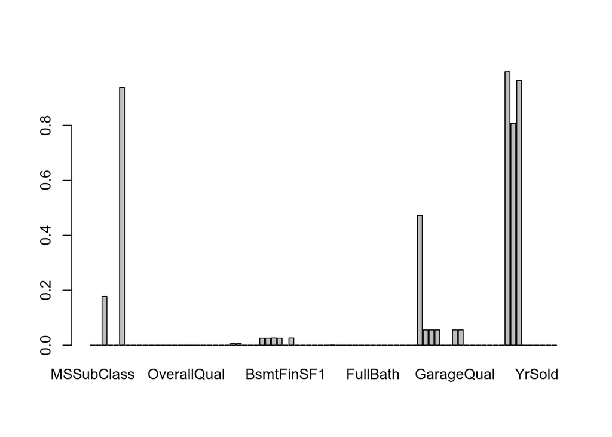

```r
barplot(perc_null_col)
```

We can see in the bar plot, there are columns such as Fence, MiscFeature, PoolQC, Alley,… with > 80 % of Null values.

I think it’s better to remove columns that have higher Percentages of Null values.

```r
#Columns that have percentage of Null values >= 70%
subset(perc_null_col, perc_null_col>=0.70)
```

```
##       Alley      PoolQC       Fence MiscFeature
##   0.9376712   0.9952055   0.8075342   0.9630137
```

```r
# Removing columns that have percentage of Null values >= 70%
df_hprice <- subset(df_hprice, select= -c(Alley, PoolQC,                                                   Fence, MiscFeature)  )
```

After Removing columns that have perc Null values >=0.70, We are left with 76 variables, but still there are some null values that we need to handle.

So just to get started quickly into regression analysis.

Filling the Null values with mean in Numeric data variables

```r
#Getting the numeric data type columns and filling it with it's mean

library(zoo)
df_hprice_numCol <- sapply(df_hprice, is.numeric)

df_hprice[df_hprice_numCol]<-lapply(df_hprice[df_hprice_numCol],na.aggregate) # na.aggregate is mean
```

Now we are left with Null values in Categorical Variables

```r
#Null values in categorical variables in Ames housing price dataset
subset(colSums(is.na(df_hprice)), colSums(is.na(df_hprice)) > 0)
```

```
##   MasVnrType     BsmtQual     BsmtCond BsmtExposure BsmtFinType1 BsmtFinType2
##            8           37           37           38           37           38
##   Electrical  FireplaceQu   GarageType GarageFinish   GarageQual   GarageCond
##            1          690           81           81           81           81
```

In above explanatory variables only (MasVnrType and Electrical) have true Null values. So we ’ill replace it with Mode

In variables such as (BsmtQual, BsmtCond, …, GarageCond), we need to replace NA -> None. Because these variables have None as actual value in Ames housing price data description.

```r
#Function to get mode of column
getmode <- function(v) {
   uniqv <- unique(v)
   uniqv[which.max(tabulate(match(v, uniqv)))]
}


# Replacing Null value in (MasVnrType and Electrical) with mode
df_hprice$MasVnrType[is.na(df_hprice$MasVnrType)]= getmode(df_hprice$MasVnrType)

df_hprice$Electrical[is.na(df_hprice$Electrical)]= getmode(df_hprice$Electrical)

# Verifying
subset(colSums(is.na(df_hprice)), colSums(is.na(df_hprice)) > 0)
```

```
##     BsmtQual     BsmtCond BsmtExposure BsmtFinType1 BsmtFinType2  FireplaceQu
##           37           37           38           37           38          690
##   GarageType GarageFinish   GarageQual   GarageCond
##           81           81           81           81
```

Atlast we need to replace above variables with Null -> “None”

```r
df_hprice <- mutate_if(df_hprice, is.factor, as.character)
df_hprice[is.na(df_hprice)] = "None"

#Converting character to factor
df_hprice <- mutate_if(df_hprice, is.character, as.factor)
```

Now we have clean dataset with zero (NULL values)

```r
colSums(is.na(df_hprice))
```

```
##    MSSubClass      MSZoning   LotFrontage       LotArea        Street
##             0             0             0             0             0
##      LotShape   LandContour     Utilities     LotConfig     LandSlope
##             0             0             0             0             0
##  Neighborhood    Condition1    Condition2      BldgType    HouseStyle
##             0             0             0             0             0
##   OverallQual   OverallCond     YearBuilt  YearRemodAdd     RoofStyle
##             0             0             0             0             0
##      RoofMatl   Exterior1st   Exterior2nd    MasVnrType    MasVnrArea
##             0             0             0             0             0
##     ExterQual     ExterCond    Foundation      BsmtQual      BsmtCond
##             0             0             0             0             0
##  BsmtExposure  BsmtFinType1    BsmtFinSF1  BsmtFinType2    BsmtFinSF2
##             0             0             0             0             0
##     BsmtUnfSF   TotalBsmtSF       Heating     HeatingQC    CentralAir
##             0             0             0             0             0
##    Electrical      1stFlrSF      2ndFlrSF  LowQualFinSF     GrLivArea
##             0             0             0             0             0
##  BsmtFullBath  BsmtHalfBath      FullBath      HalfBath  BedroomAbvGr
##             0             0             0             0             0
##  KitchenAbvGr   KitchenQual  TotRmsAbvGrd    Functional    Fireplaces
##             0             0             0             0             0
##   FireplaceQu    GarageType   GarageYrBlt  GarageFinish    GarageCars
##             0             0             0             0             0
##    GarageArea    GarageQual    GarageCond    PavedDrive    WoodDeckSF
##             0             0             0             0             0
##   OpenPorchSF EnclosedPorch     3SsnPorch   ScreenPorch      PoolArea
##             0             0             0             0             0
##       MiscVal        MoSold        YrSold      SaleType SaleCondition
##             0             0             0             0             0
##     SalePrice
##             0
```

### Changing the Date related variables to factor

```r
df_hprice$YearBuilt <- as.factor(df_hprice$YearBuilt)
df_hprice$YearRemodAdd <- as.factor(df_hprice$YearRemodAdd)
df_hprice$GarageYrBlt <- as.factor(df_hprice$GarageYrBlt)
df_hprice$YrSold <- as.factor(df_hprice$YrSold)
df_hprice$MoSold <- as.factor(df_hprice$MoSold)
```

### Starting with Regression Analysis

(I am following the approach mentioned in OpenIntro Stats Book).

Our objective is to predict the SalePrice based on efficient model!

To get started making linear model using all 76 explanatory variables in Ames Housing Price dataset

### Full Model

```r
full_model <- lm(SalePrice ~ ., data =df_hprice)

summary(full_model)
```

```
##
## Call:
## lm(formula = SalePrice ~ ., data = df_hprice)
##
## Residuals:
##     Min      1Q  Median      3Q     Max
## -182228   -8425       0    8620  182228
##
## Coefficients: (15 not defined because of singularities)
##                               Estimate Std. Error t value Pr(>|t|)
## (Intercept)                 -8.889e+05  8.463e+04 -10.504  < 2e-16 ***
## MSSubClass                  -6.651e+01  1.036e+02  -0.642 0.521018
## MSZoningFV                   3.716e+04  1.510e+04   2.461 0.014024 *
## MSZoningRH                   2.223e+04  1.597e+04   1.392 0.164116
## MSZoningRL                   3.203e+04  1.345e+04   2.381 0.017469 *
## MSZoningRM                   2.527e+04  1.288e+04   1.962 0.050098 .
## LotFrontage                  7.629e+01  5.064e+01   1.506 0.132305
## LotArea                      7.151e-01  1.282e-01   5.580 3.14e-08 ***
## StreetPave                   2.385e+04  1.510e+04   1.580 0.114510
## LotShapeIR2                  1.242e+03  4.810e+03   0.258 0.796258
## LotShapeIR3                  5.606e+03  9.741e+03   0.575 0.565129
## LotShapeReg                  2.548e+03  1.871e+03   1.362 0.173546
## LandContourHLS               9.893e+03  6.415e+03   1.542 0.123346
## LandContourLow              -6.501e+03  7.892e+03  -0.824 0.410291
## LandContourLvl               4.601e+03  4.841e+03   0.950 0.342117
## UtilitiesNoSeWa             -2.761e+04  2.940e+04  -0.939 0.347947
## LotConfigCulDSac             1.003e+04  3.871e+03   2.590 0.009734 **
## LotConfigFR2                -9.550e+03  4.525e+03  -2.111 0.035073 *
## LotConfigFR3                -2.247e+04  1.361e+04  -1.651 0.099095 .
## LotConfigInside             -2.139e+03  2.113e+03  -1.013 0.311517
## LandSlopeMod                 6.336e+03  4.856e+03   1.305 0.192324
## LandSlopeSev                -5.157e+04  1.427e+04  -3.615 0.000316 ***
## NeighborhoodBlueste         -5.127e+03  2.263e+04  -0.227 0.820832
## NeighborhoodBrDale           4.984e+03  1.307e+04   0.381 0.703061
## NeighborhoodBrkSide         -8.038e+03  1.103e+04  -0.729 0.466228
## NeighborhoodClearCr         -1.491e+04  1.046e+04  -1.425 0.154626
## NeighborhoodCollgCr         -9.507e+03  7.999e+03  -1.189 0.234895
## NeighborhoodCrawfor          5.715e+03  9.820e+03   0.582 0.560720
## NeighborhoodEdwards         -1.949e+04  8.916e+03  -2.186 0.029028 *
## NeighborhoodGilbert         -1.024e+04  8.519e+03  -1.202 0.229590
```

[output cut: 486 more lines]

```
## SaleTypeCWD                  2.186e+04  1.581e+04   1.382 0.167182
## SaleTypeNew                  1.187e+04  1.790e+04   0.663 0.507403
## SaleTypeOth                  4.420e+03  1.768e+04   0.250 0.802634
## SaleTypeWD                  -2.121e+03  4.990e+03  -0.425 0.670870
## SaleConditionAdjLand         9.255e+03  1.741e+04   0.531 0.595205
## SaleConditionAlloca         -5.095e+03  1.157e+04  -0.440 0.659886
## SaleConditionFamily         -5.351e+03  6.919e+03  -0.773 0.439463
## SaleConditionNormal          4.450e+03  3.385e+03   1.315 0.188977
## SaleConditionPartial         2.119e+03  1.709e+04   0.124 0.901320
## ---
## Signif. codes:  0 '***' 0.001 '**' 0.01 '*' 0.05 '.' 0.1 ' ' 1
##
## Residual standard error: 23300 on 950 degrees of freedom
## Multiple R-squared:  0.944,  Adjusted R-squared:  0.914
## F-statistic: 31.46 on 509 and 950 DF,  p-value: < 2.2e-16
```

Summary Statistics tells that 91.4 % of variability in SalesPrice can be explained by our least square Full model!

Now, in this full model there are all explanatory variables but some of them are statistically significant and some are not. So in order to identify the features that more helpful in explaining the SalesPrice.

There are two strategies -> Backward Elimination and Forward Selection (Using Adjusted R Square or p values in each strategy)

We ill be using the Backward Elimination Strategy to identify the best explanatory variables that are contributing in explaining the SalesPrice (Target Variable)

### Identifying explanatory variables using Backward Elimination Strategy

I am using step function (Just following the approach mentioned in OpenIntro Stats Book) because I haven’t yet studied about multicollinearity problem!

```r
new_model <- step(full_model, direction = "backward")
```

```
## Start:  AIC=29756.34
## SalePrice ~ MSSubClass + MSZoning + LotFrontage + LotArea + Street +
##     LotShape + LandContour + Utilities + LotConfig + LandSlope +
##     Neighborhood + Condition1 + Condition2 + BldgType + HouseStyle +
##     OverallQual + OverallCond + YearBuilt + YearRemodAdd + RoofStyle +
##     RoofMatl + Exterior1st + Exterior2nd + MasVnrType + MasVnrArea +
##     ExterQual + ExterCond + Foundation + BsmtQual + BsmtCond +
##     BsmtExposure + BsmtFinType1 + BsmtFinSF1 + BsmtFinType2 +
##     BsmtFinSF2 + BsmtUnfSF + TotalBsmtSF + Heating + HeatingQC +
##     CentralAir + Electrical + `1stFlrSF` + `2ndFlrSF` + LowQualFinSF +
##     GrLivArea + BsmtFullBath + BsmtHalfBath + FullBath + HalfBath +
##     BedroomAbvGr + KitchenAbvGr + KitchenQual + TotRmsAbvGrd +
##     Functional + Fireplaces + FireplaceQu + GarageType + GarageYrBlt +
##     GarageFinish + GarageCars + GarageArea + GarageQual + GarageCond +
##     PavedDrive + WoodDeckSF + OpenPorchSF + EnclosedPorch + `3SsnPorch` +
##     ScreenPorch + PoolArea + MiscVal + MoSold + YrSold + SaleType +
##     SaleCondition
##
##
## Step:  AIC=29756.34
## SalePrice ~ MSSubClass + MSZoning + LotFrontage + LotArea + Street +
##     LotShape + LandContour + Utilities + LotConfig + LandSlope +
##     Neighborhood + Condition1 + Condition2 + BldgType + HouseStyle +
##     OverallQual + OverallCond + YearBuilt + YearRemodAdd + RoofStyle +
##     RoofMatl + Exterior1st + Exterior2nd + MasVnrType + MasVnrArea +
##     ExterQual + ExterCond + Foundation + BsmtQual + BsmtCond +
##     BsmtExposure + BsmtFinType1 + BsmtFinSF1 + BsmtFinType2 +
##     BsmtFinSF2 + BsmtUnfSF + TotalBsmtSF + Heating + HeatingQC +
##     CentralAir + Electrical + `1stFlrSF` + `2ndFlrSF` + LowQualFinSF +
##     BsmtFullBath + BsmtHalfBath + FullBath + HalfBath + BedroomAbvGr +
##     KitchenAbvGr + KitchenQual + TotRmsAbvGrd + Functional +
##     Fireplaces + FireplaceQu + GarageType + GarageYrBlt + GarageFinish +
##     GarageCars + GarageArea + GarageQual + GarageCond + PavedDrive +
##     WoodDeckSF + OpenPorchSF + EnclosedPorch + `3SsnPorch` +
##     ScreenPorch + PoolArea + MiscVal + MoSold + YrSold + SaleType +
##     SaleCondition
##
##
## Step:  AIC=29756.34
## SalePrice ~ MSSubClass + MSZoning + LotFrontage + LotArea + Street +
```

[output cut: 2254 more lines]

```
## - PoolArea       1 1.5480e+10 7.1007e+11 29496
## - MSSubClass     1 1.7365e+10 7.1195e+11 29499
## - SaleCondition  5 2.3471e+10 7.1806e+11 29504
## - LotArea        1 2.1449e+10 7.1604e+11 29508
## - BsmtQual       3 2.3747e+10 7.1833e+11 29508
## - KitchenQual    3 2.5842e+10 7.2043e+11 29513
## - OverallQual    1 2.6208e+10 7.2079e+11 29517
## - OverallCond    1 2.8194e+10 7.2278e+11 29522
## - BsmtExposure   4 3.7250e+10 7.3184e+11 29534
## - BsmtFinSF1     1 3.8139e+10 7.3272e+11 29541
## - `1stFlrSF`     1 4.7648e+10 7.4223e+11 29560
## - Condition2     7 8.2868e+10 7.7745e+11 29616
## - Neighborhood  24 1.0923e+11 8.0382e+11 29631
## - `2ndFlrSF`     1 1.5324e+11 8.4783e+11 29754
## - RoofMatl       7 2.6041e+11 9.5500e+11 29916
```

```r
summary(new_model)
```

```
##
## Call:
## lm(formula = SalePrice ~ MSSubClass + MSZoning + LotFrontage +
##     LotArea + Street + LandContour + Utilities + LotConfig +
##     LandSlope + Neighborhood + Condition1 + Condition2 + OverallQual +
##     OverallCond + RoofMatl + Exterior1st + MasVnrArea + ExterQual +
##     Foundation + BsmtQual + BsmtExposure + BsmtFinType1 + BsmtFinSF1 +
##     BsmtFinSF2 + BsmtUnfSF + HeatingQC + `1stFlrSF` + `2ndFlrSF` +
##     FullBath + BedroomAbvGr + KitchenAbvGr + KitchenQual + TotRmsAbvGrd +
##     Functional + Fireplaces + GarageFinish + GarageCars + GarageArea +
##     GarageQual + GarageCond + WoodDeckSF + ScreenPorch + PoolArea +
##     SaleCondition, data = df_hprice)
##
## Residuals:
##     Min      1Q  Median      3Q     Max
## -175208   -9329      26   10201  175208
##
## Coefficients: (3 not defined because of singularities)
##                        Estimate Std. Error t value Pr(>|t|)
## (Intercept)          -6.929e+05  4.647e+04 -14.910  < 2e-16 ***
## MSSubClass           -1.354e+02  2.364e+01  -5.729 1.25e-08 ***
## MSZoningFV            3.585e+04  1.139e+04   3.147 0.001686 **
## MSZoningRH            2.376e+04  1.149e+04   2.069 0.038748 *
## MSZoningRL            2.984e+04  9.736e+03   3.065 0.002222 **
## MSZoningRM            2.407e+04  9.125e+03   2.637 0.008454 **
## LotFrontage           9.000e+01  4.067e+01   2.213 0.027086 *
## LotArea               6.006e-01  9.433e-02   6.368 2.65e-10 ***
## StreetPave            3.243e+04  1.128e+04   2.876 0.004091 **
## LandContourHLS        9.511e+03  4.963e+03   1.917 0.055505 .
## LandContourLow       -6.476e+03  6.036e+03  -1.073 0.283555
## LandContourLvl        6.764e+03  3.540e+03   1.911 0.056251 .
## UtilitiesNoSeWa      -3.385e+04  2.444e+04  -1.385 0.166220
## LotConfigCulDSac      8.921e+03  3.149e+03   2.833 0.004677 **
## LotConfigFR2         -7.668e+03  3.898e+03  -1.967 0.049361 *
## LotConfigFR3         -1.613e+04  1.250e+04  -1.291 0.197064
## LotConfigInside      -1.215e+03  1.721e+03  -0.706 0.480280
## LandSlopeMod          6.180e+03  3.786e+03   1.632 0.102873
## LandSlopeSev         -2.794e+04  9.914e+03  -2.819 0.004894 **
## NeighborhoodBlueste   5.214e+03  1.824e+04   0.286 0.775018
## NeighborhoodBrDale    1.892e+03  9.951e+03   0.190 0.849244
```

[output cut: 120 more lines]

```
## GarageCondTA          1.048e+05  3.187e+04   3.289 0.001032 **
## WoodDeckSF            1.143e+01  5.663e+00   2.019 0.043712 *
## ScreenPorch           2.139e+01  1.198e+01   1.785 0.074418 .
## PoolArea              9.388e+01  1.736e+01   5.409 7.51e-08 ***
## SaleConditionAdjLand  8.864e+03  1.271e+04   0.697 0.485681
## SaleConditionAlloca   6.103e+03  8.100e+03   0.753 0.451298
## SaleConditionFamily  -1.078e+03  5.892e+03  -0.183 0.854874
## SaleConditionNormal   6.227e+03  2.617e+03   2.379 0.017480 *
## SaleConditionPartial  2.205e+04  3.639e+03   6.059 1.79e-09 ***
## ---
## Signif. codes:  0 '***' 0.001 '**' 0.01 '*' 0.05 '.' 0.1 ' ' 1
##
## Residual standard error: 23000 on 1313 degrees of freedom
## Multiple R-squared:  0.9246, Adjusted R-squared:  0.9162
## F-statistic: 110.2 on 146 and 1313 DF,  p-value: < 2.2e-16
```

After applying the backward elimination strategy our Adjusted R squared has little bit improved From 91.4% to 91.62%.

And new_model consist of 44 explanatory variables compare to full_model that consist of all 76 explanatory variables.

Hence our new_model is better than full_model.

### Model Diagnositic

1. Linearity

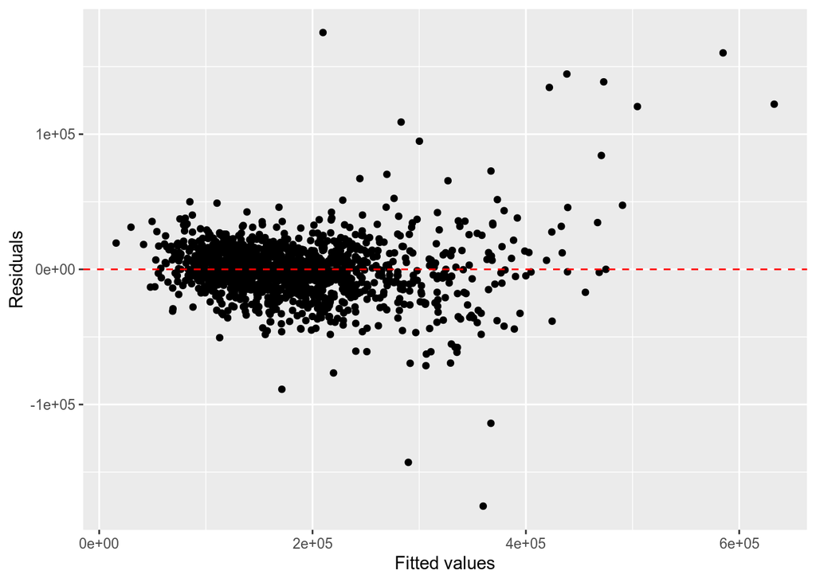

```r
ggplot(data = new_model, aes(x = .fitted, y = .resid)) +
  geom_point() +
  geom_hline(yintercept = 0, linetype = "dashed", color = "red") +
  xlab("Fitted values") +
  ylab("Residuals")
```

Residuals are not nearly random scatterd which means there is a need for transformation in explanatory variables and also condition of constant variability in residuals is violated

2. Nearly Normal Residuals

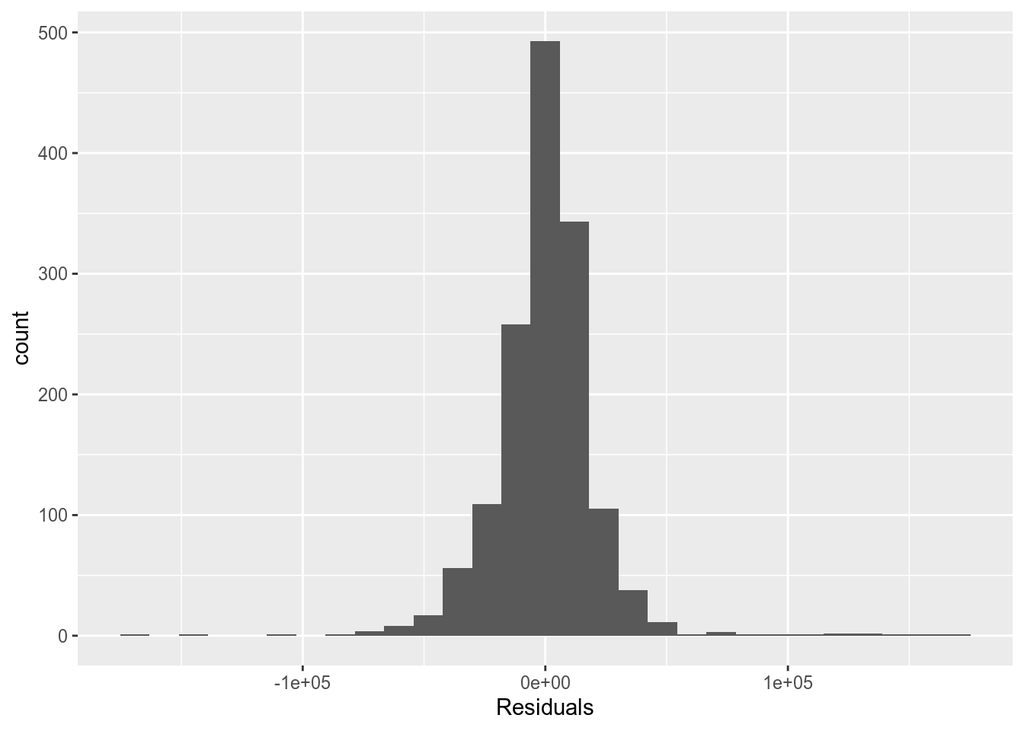

```r
ggplot(data = new_model, aes(x = .resid)) +
  geom_histogram() +
  xlab("Residuals")
```

There are some positive outliers in extreme right!

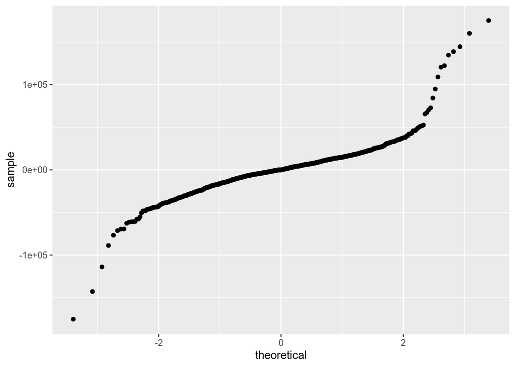

```r
ggplot(data = new_model, aes(sample = .resid)) +
  stat_qq()
```

Normal Quantile-Quantile also shows that new_model residuals are not nearly normal.

Hence the new_model can also be improved!

by appropriate transformations in explanatory varaibles. by tackling multicollinearity problem.